# Ford GoBike System Usage Pattern in February, 2019

## by (Faith Ugwu)

## Investigation Overview

> For the presentation, I focused solely on Ford GoBike system usage based on duration, user type, gender, start hour, and day.

## Dataset Overview

> The dataset includes information about individual rides made in a bike-sharing system covering the greater San Francisco Bay area in February, 2019. The visualizations below were created using wrangled and cleaned data to aid in exploration and the discovery of usage patterns by riders. The original dataset has 183412 rows and 16 columns; after wrangling, the dataset has 174952 rows and 20 columns.

## Distribution of Duration

> Duration has a long-tailed distribution, with a lot of bike rides on the lower minute duration, and few on the higher minutes duration. When plotted on a log-scale, the distribution is symmetric and unimodal, with most rides between 8-12 minutes, and very few rides lasting more then 60 minutes.

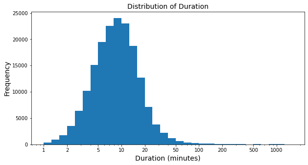

## Bike Usage based on User Type

> There are over 90% of subscriber user types.

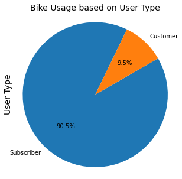

## Bike Usage based on Gender

> Male bike riders are about 3 times of female bike riders.

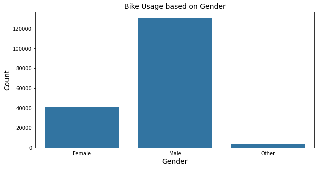

## Bike Usage based on Day of the Week

> Bikes were mostly used on work days (Monday-Friday).

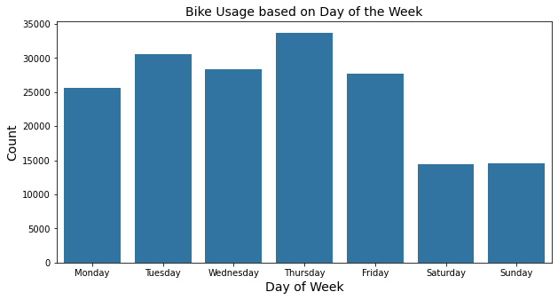

## Bike Usage based on Hour of the Day

> Most rides occur at 8:00am and 5:00pm. This is due to the fact that most work days begin and end around this time.

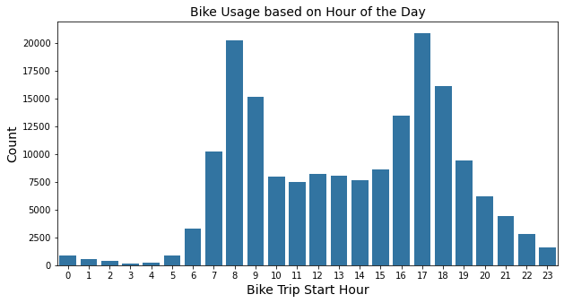

## Average Bike Duration based on User Type

> Most customers rode bikes within 15 minutes while most subscribers rode bikes within 10 minutes. Customers were also more likely to ride longer than one hour when compared to subscriber users.

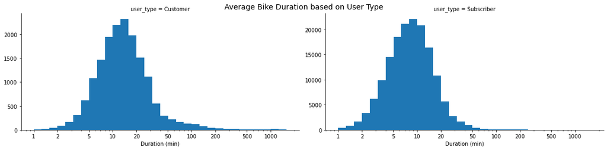

## Average Bike duration based gender and user in terms of weekdays

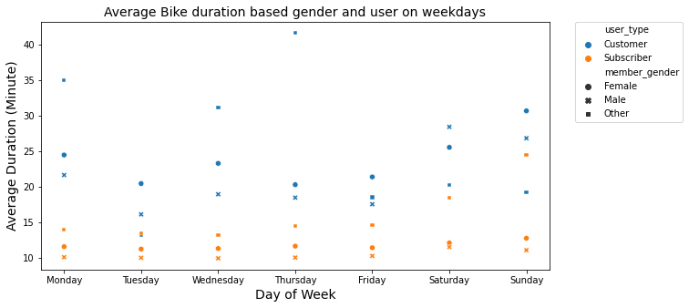